# Elegant and explanatory vulcano plots in R ggplot2

### Creating new factor variable neccesary for demonstration of displaying factor categories on the vulcano plots

Lets create some new columns that will inform us wheter the particular gene codes for complex I accesory subunit or ribosomes subunits is biologically significant and belongs to an arbitrary category. For creating a new column we use mutate() function. Inside we name the columns ex. New column “Category” was created and the result of case_when() function were assigned to it. Inside case_when() grepl() search for gene names starting with NDUF or RPS or RPL. For easy ploting we should change the data type of this new column to a factor type with as.factor() function.

```r
# Creating factor "Complex_I"  for genes contaning "NDUF" in their names and "Ribosome_large_subunit_" and "Ribosome_small_subunit" for genes containing RPSorRPL+number in their names

Data_for_Vulcan <- Data_for_Vulcan %>% mutate(Category = case_when(
                                                   grepl("NDUF.*", genes) ~ "Complex_I",
                                                   grepl("RPS.*", genes) ~ "Ribosome_small_subunit",
                                                   grepl("RPL.*", genes)~ "Ribosome_large_subuinit",
                                                   TRUE~ "Other")
                                               )

# Changing Category variable datatype from character into factor
Data_for_Vulcan$Category <- as.factor(Data_for_Vulcan$Category)

# Displaying counts of different factor categories of Category variable
table(Data_for_Vulcan$Category)
```

```
##
##               Complex_I                   Other Ribosome_large_subuinit
##                      22                    1574                      38
##  Ribosome_small_subunit
##                      29
```

```r
# Creating a new column for significant results with fold x 2 and p-value < 0.05

# Recalculating log p - value
p_value <-  0.05
logp_value <- log10(p_value) # = -1.30103
# Undo log:
print(paste("p_value treshold is set up as", 10^logp_value)) # = 0.05  - the log10 for 0.05 is ~ -1.3
```

```
## [1] "p_value treshold is set up as 0.05"
```

```r
                   #ifelse(test, co zrobić jak true, co jak false)
Data_for_Vulcan <- Data_for_Vulcan %>% mutate(Significant = case_when(
                                          #Creating categories
                                          Logdiff < - 1 & p_value > 1.30103 ~ "Depleted",
                                          Logdiff > 1 & p_value > 1.30103 ~ "Upregulated" ,
                                          Logdiff > -1 | Logdiff < 1~ "Not-Significant"
                                                                     )
                                              )
# Changing to factor datatype
Data_for_Vulcan$Significant <- as.factor(Data_for_Vulcan$Significant)
# Lets see how many are significant
table(Data_for_Vulcan$Significant)
```

```
##
##        Depleted Not-Significant     Upregulated
##             143            1474              46
```

```r
# Additional column to demonstrate collor palletes (devides the observations equally to numbers 1,2,3,4,5,6)
Data_for_Vulcan <- Data_for_Vulcan %>% mutate(Set = case_when(
                                        row_number()%in% 1368:1663 ~ "Color_1",
                                        row_number()%in% 1091:1367 ~ "Color_2",
                                        row_number()%in% 814:1090 ~ "Color_3",
                                        row_number()%in% 537:813 ~ "Color_4",
                                        row_number()%in% 260:536 ~ "Color_5",
                                        row_number()%in% 1:259 ~ "Color_6"
                                                              )
                                              )
 str(Data_for_Vulcan)
```

```
## tibble [1,663 x 6] (S3: tbl_df/tbl/data.frame)
##  $ genes      : chr [1:1663] "RBM39" "NDUFS6" "DNPH1" "MTHFD2" ...
##  $ p_value    : num [1:1663] 1.045 2.177 0.355 1.914 0.912 ...
##  $ Logdiff    : num [1:1663] -0.528 1.187 -0.237 -1.811 0.392 ...
##  $ Category   : Factor w/ 4 levels "Complex_I","Other",..: 2 1 2 2 2 2 2 2 2 2 ...
##  $ Significant: Factor w/ 3 levels "Depleted","Not-Significant",..: 2 3 2 1 2 2 1 2 2 3 ...
##  $ Set        : chr [1:1663] "Color_6" "Color_6" "Color_6" "Color_6" ...
```

```r
 table(Data_for_Vulcan$Set)
```

```
##
## Color_1 Color_2 Color_3 Color_4 Color_5 Color_6
##     296     277     277     277     277     259
```

## Creating vulcano plot step by step

Library(ggplot2) is the most commonly used and a really powerful r library for data visualisation. It is based on the paradigm of grammar of graphics in which visualisations objects are build step by steb by introducing subseqent layers of information. We start creating a plot by calling ggplot() function in which we define the data source and basic aestetics aes() of cartesian cordinates(x,y etc.) which tells R how to represent data on the plot. Then we add geoms such as points (geom_point(), histogram - geom_hist() etc. It is important to highligh that every layer of ggplot2 object may inherit aestetics from the previous layer or have its own defined for example color based on categorical variable. It is also importand to distinguish aestetics and atributes. Aestetics are put in side aes() function and tell R how to display anything based on data, the atributes are introduced outside aes() and are purely graphical not based on data. The structure of the plot looks like that:

```
Name of the plot object <- ggplot(data = Table_1, aes(x = Column_1, y = Column_2, color = anyVariable))+
                           geom_point(color = "green", size = 12)
```

Here color and size inside geom_point() are atributes not aestethics. The color = anyVariable is an aestetic declaration which will color some points according to data in a particular column.

### Createing very basic vulcano plot with ggplot2 library and controling for overplotting

Below is a very basic vulcano plot created in ggplot2 by geom_point() function. To make it publishable quality we need to customise a little:

1. Control for overplotting - by introducing small random noise to points position(jittering) or using alpha transparency of points
2. We need to set proper title, subtitle and axis titles as well as legend
3. We need to color the points that are statistically significant
4. We need to change the x axis to be symetrical so it will be easy for the reader to compare up and downregulated protein/genes
5. We may color the points for an interesting category of proteins/genes
6. We may atribute the size and color artibutes of points to highlight the most imortant results
7. We may introduce a custom scientific journal color pallete
8. We should modify or remove the default plot background
9. We should increase the fonts to be big enough for a particular output

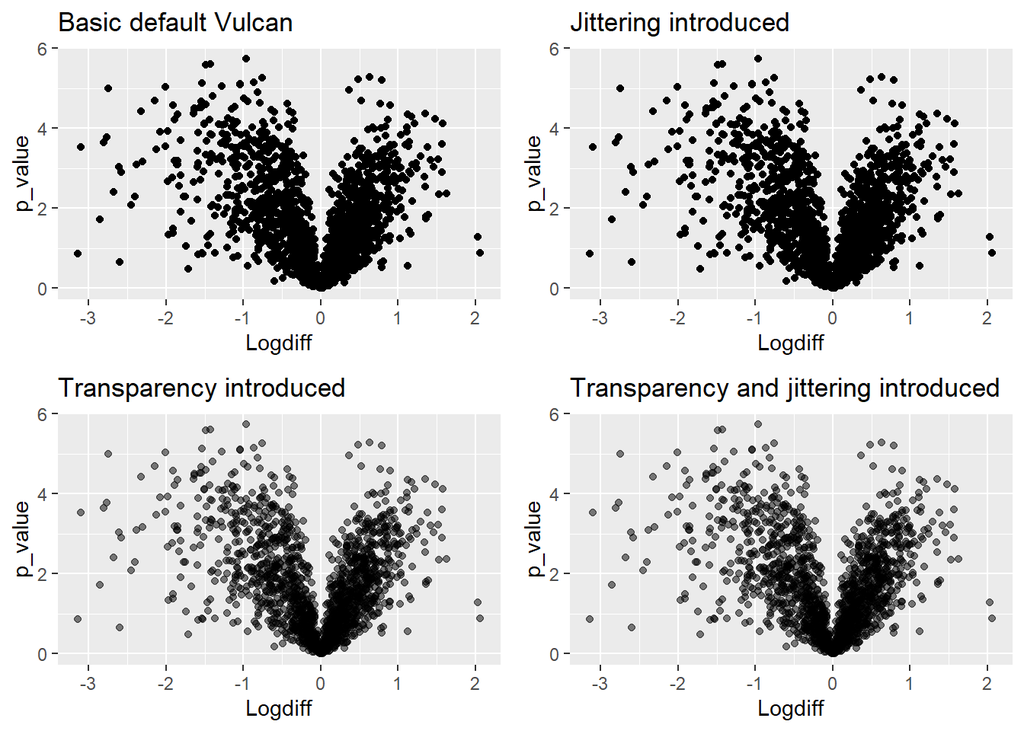

```r
# Basic Vulcano plot with ggplot2 library

library(ggplot2)


#Library for creating a graphics grid
library(gridExtra)
Basic_Vulcan <- ggplot(Data_for_Vulcan, aes(x = Logdiff , y = p_value))+
                geom_point()+
                #This is how we introduce the plot title
                labs(title = "Basic default Vulcan")

Basic_Vulcan_jitter <- ggplot(Data_for_Vulcan, aes(x = Logdiff , y = p_value))+
                       geom_jitter()+
                       labs(title = "Jittering introduced")

Basic_Vulcan_transparent_points <- ggplot(Data_for_Vulcan, aes(x = Logdiff , y = p_value))+
                                   geom_point(alpha = 0.5)+
                                    labs(title = "Transparency introduced")

Basic_Vulcan_transparent_points_jittered <- ggplot(Data_for_Vulcan, aes(x = Logdiff , y = p_value))+
                                            geom_jitter(alpha = 0.5)+
                                            labs(title = "Transparency and jittering introduced")

# arrange plots into two rows and two columns
Set_1 <- grid.arrange(Basic_Vulcan, Basic_Vulcan_jitter, Basic_Vulcan_transparent_points, Basic_Vulcan_transparent_points_jittered, ncol = 2, nrow = 2 )
```

### Creating equall sized x scales and fixing aspect ratio of the plots

Whe may fix the aspect ratio with coord_fixed() if we would like to compare different datasets and easly arrange them in a grid layout of multiple rectangles with the same scales.

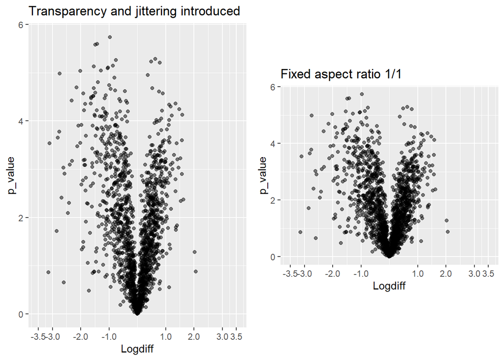

```r
# limit and breaks of the x axis
Basic_Vulcan_scale <- Basic_Vulcan_transparent_points_jittered +
                      scale_x_continuous(limits = c(-3.5, 3.5),
                                         breaks = c(-3.5, -3,-2,-1,1,2,3, 3.5))


#  Whe may fix the aspect ratio with fixed scales if we would like to compare different datasets abd easly arrange them in a grid layout of multiple squares

Basic_Vulcan_squareshape <- Basic_Vulcan_scale +
                            coord_fixed(ratio = 1/1) +
                            labs(title = "Fixed aspect ratio 1/1")


grid.arrange(Basic_Vulcan_scale, Basic_Vulcan_squareshape, ncol=2)
```

### Assigning categories to points

```
Categorical data may be represented as color, shape , size and transparency but it is adviced to use discrete colors
```

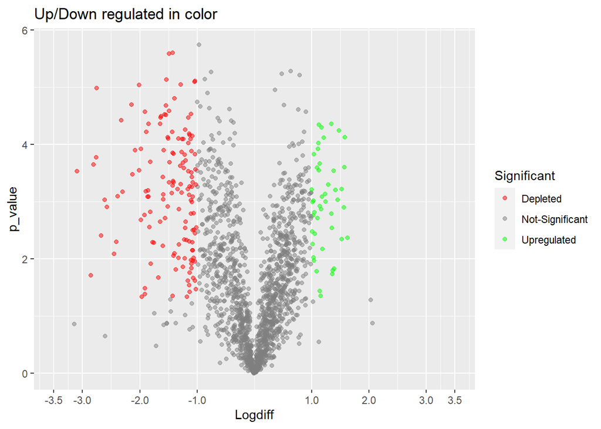

```r
# Assigning colors for significant hits

Basic_Vulcan_colored_categories <-  ggplot(Data_for_Vulcan, aes(x = Logdiff , y = p_value, col = Significant))+
                                    geom_jitter(alpha = 0.5)+
                                    scale_x_continuous(limits = c(-3.5, 3.5),
                                                       breaks = c(-3.5, -3,-2,-1,1,2,3, 3.5))+
                                    coord_fixed(ratio = 1/1)+
                                    labs(title = "Up/Down regulated in color")+
                                   # changing colors
                                    scale_color_manual(values = c("red","gray50", "green"), na.translate = TRUE)

  # Ovverriding alpha transparency for significant hits and assigning custom color by creating second layer of points
  Basic_Vulcan_colored_categories_2 <-  ggplot(Data_for_Vulcan, aes(x = Logdiff , y = p_value), color = "gray20")+
                                        geom_jitter(alpha = 0.5)+
                                        scale_x_continuous(limits = c(-3.5, 3.5),
                                                           breaks = c(-3.5, -3,-2,-1,1,2,3, 3.5))+
                                        coord_fixed(ratio = 1/1)+
                                        labs(title = "Overide color layer")+

  # Additional layers of points only for particular categories
             geom_point(data = Data_for_Vulcan[Data_for_Vulcan$Significant == "Depleted" , ],
                        color= "red")+
             geom_point(data = Data_for_Vulcan[Data_for_Vulcan$Significant == "Upregulated" , ],
                        color= "green")


   #setting up colors according to biomit guidelines (Red- depleted , Green - upregulated)

Basic_Vulcan_colored_categories
```

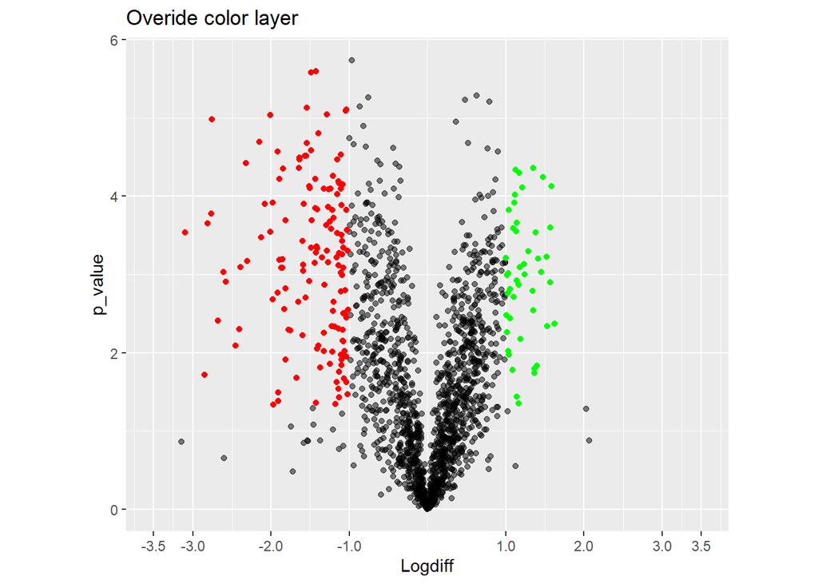

```r
Basic_Vulcan_colored_categories_2
```

### Assigning size atribute to points to highliting most important results

You can assign size atribute to points dependant on fold, p. value or both so that the most important resulats become bigger points.

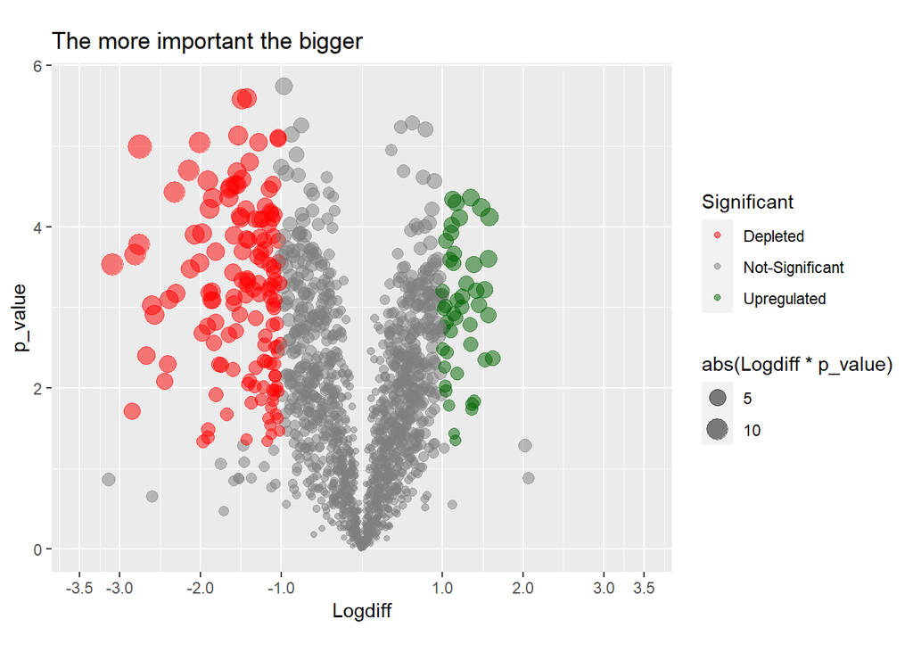

```r
# Introducing size atribute for Logdiiff x squared p-value

Vulcan_size_highliting <- ggplot(Data_for_Vulcan, aes(x = Logdiff ,
                                                      y = p_value,
                                                      col = Significant,
                                                      size = abs(Logdiff*p_value)))+
                                  geom_jitter(alpha = 0.5)+
                                  scale_x_continuous(limits = c(-3.5, 3.5),
                                                     breaks = c(-3.5, -3,-2,-1,1,2,3, 3.5))+
                                  coord_fixed(ratio = 1/1)+
                                  labs(title = "The more important the bigger")+
  # changing colors
                                  scale_color_manual(values = c("red","gray50", "darkgreen"),
                                                     na.translate = TRUE)

Vulcan_size_highliting
```

### Displaying categorical data on vulcano plots

The default point produced by geom_point() function has only the color atribute - the ones with numbers from 21 have also fill atribute - by combining both it is possible to plot two types of categorical data at once for example - all the significant hits that belong to complex I category. However it may be more explanatory to create two faceted plots one be one in such a case or use shape attribute.

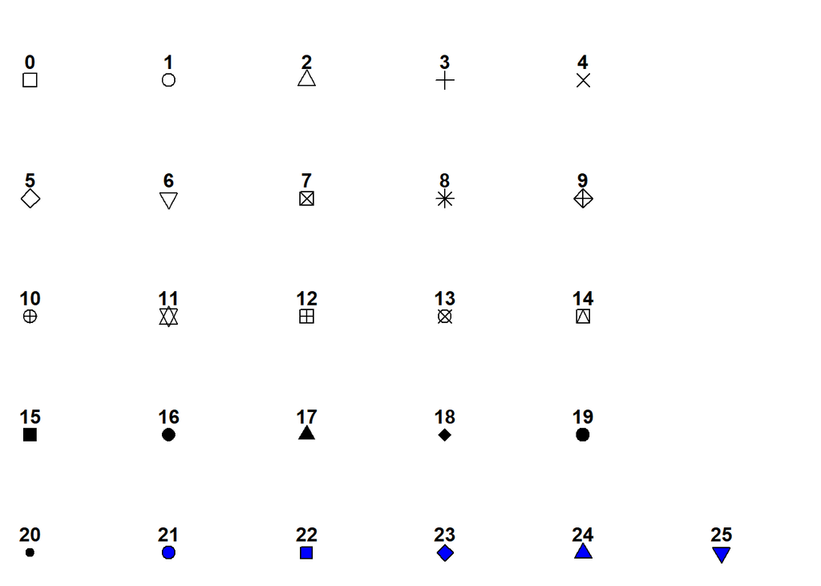

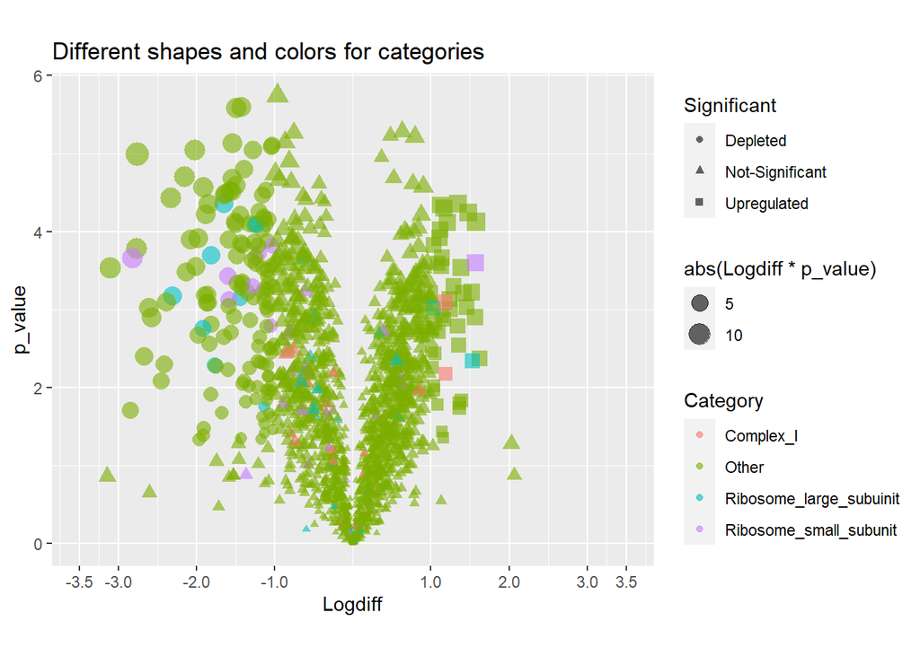

```r
# Displaying two categorical variables with color and shape
Vulcan_categorical <- ggplot(Data_for_Vulcan, aes(x = Logdiff ,
                                                  y = p_value,
                                                  shape = Significant,
                                                  size = abs(Logdiff*p_value),
                                                  color = Category))+
                      geom_jitter(alpha = 0.6)+
                      scale_x_continuous(limits = c(-3.5, 3.5),
                                         breaks = c(-3.5, -3,-2,-1,1,2,3, 3.5))+
                      coord_fixed(ratio = 1/1)+
                      labs(title = "Different shapes and colors for categories")

Vulcan_categorical
```

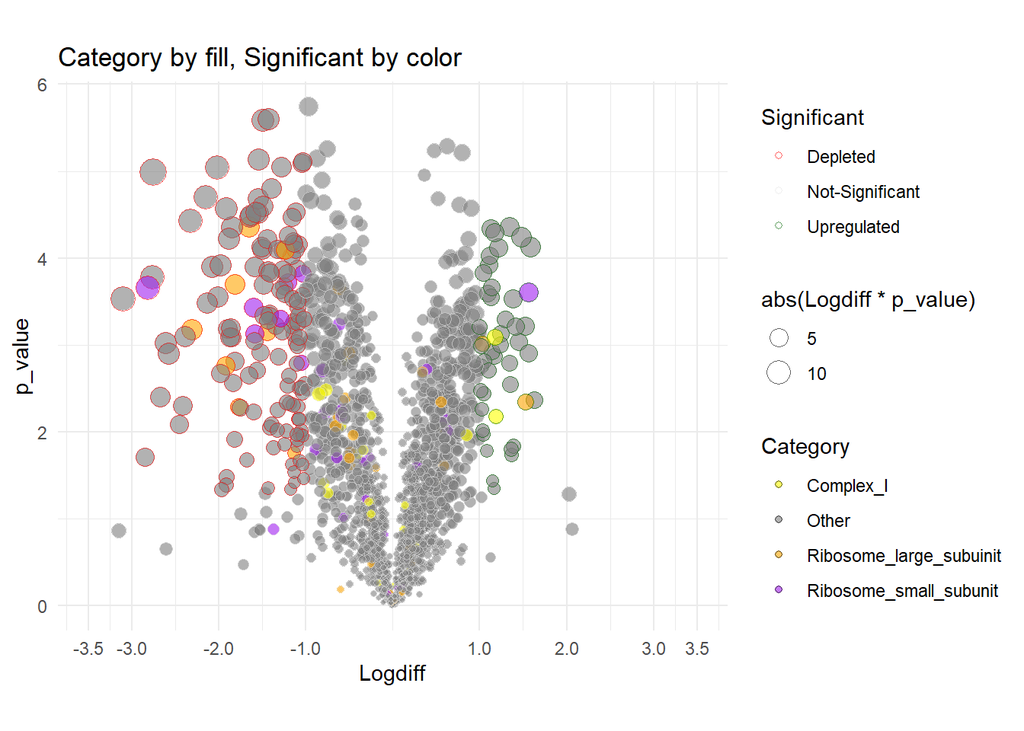

```r
#When displaying two categorical variables with color and fill you must use shape numbers from 21 to 25
Vulcan_categorical_fill_color <- ggplot(Data_for_Vulcan, aes(x = Logdiff,
                                                             y = p_value,
                                                             size = abs(Logdiff*p_value),
                                                             fill = Category,
                                                             color = Significant))+
                                  geom_jitter(alpha = 0.6, shape = 21)+
                                  scale_x_continuous(limits = c(-3.5, 3.5),
                                                     breaks = c(-3.5, -3,-2,-1,1,2,3, 3.5))+
                                  coord_fixed(ratio = 1/1)+
                                  labs(title = "Category by fill, Significant by color")+
  # Different color scales must be used to distinguish fill and color
                                  scale_color_manual(values = c("red","gray90","darkgreen"))+
                                  scale_fill_manual(values = c("yellow", "gray50", "orange", "purple"))+
                                 # different theme background
                                  theme_minimal()


Vulcan_categorical_fill_color
```

### Introducing custom color scales from scientific journals such as Nature of Lancet

```
 Library(ggsci) provides color palletes used by top tier biomedical journals. Here are some examples:
```

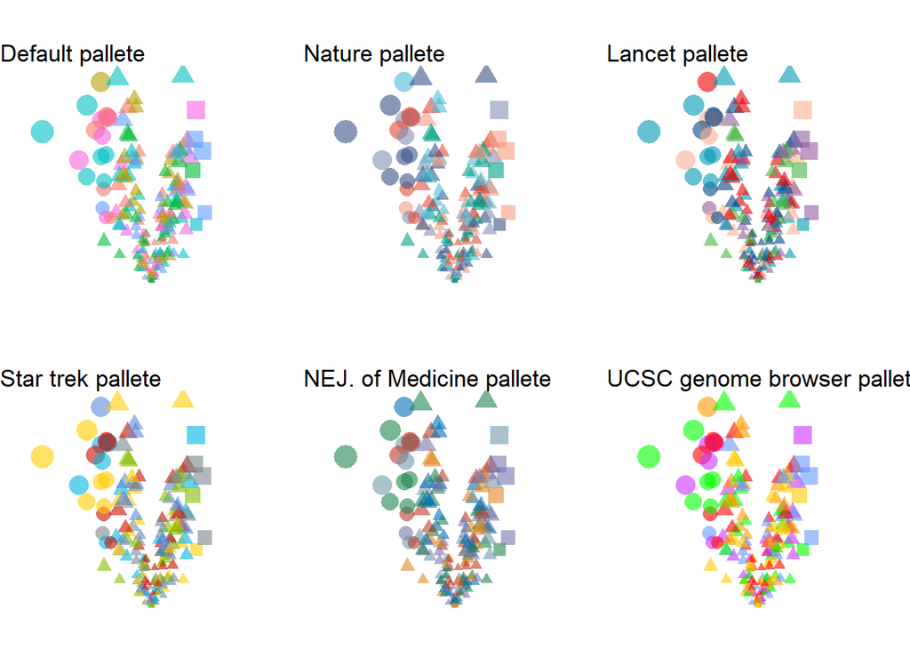

```r
#scientific palletes
library(ggsci)
                                              #display only a sample of 200 points
Vulcan_custom_colors <- ggplot(Data_for_Vulcan[sample(1:1663, 200), ],
                               aes(x = Logdiff ,
                                   y = p_value,
                                   size = abs(Logdiff*p_value),
                                   col = Set,
                                   shape = Significant))+
                        geom_jitter(alpha = 0.6 )+
                        scale_x_continuous(limits = c(-3.5, 3.5),
                                           breaks = c(-3.5, -3,-2,-1,1,2,3, 3.5))+
                        coord_fixed(ratio = 1/1)+
                        labs(title = "Default pallete")+
                        # striping axis and background and legends
                        theme_void()+
                        theme(legend.position = "none")

# Some examples of colors palletes availible in ggsci:

  # Nature color pallete
Vulcan_colors_nature <- Vulcan_custom_colors + scale_color_npg()+
                        labs(title = "Nature pallete")
  # Lancet color pallete
Vulcan_colors_Lancet <- Vulcan_custom_colors + scale_color_lancet()+
                        labs(title = "Lancet pallete")
  #  Star trek color pallete
Vulcan_colors_startrek <- Vulcan_custom_colors + scale_color_startrek()+
                        labs(title = "Star trek pallete")
# New England Journal of Medicine pallete
Vulcan_color_nejm <- Vulcan_custom_colors + scale_color_nejm()+
                        labs(title = "NEJ. of Medicine pallete")
# UCSC genome browser pallete
Vulcan_color_ucsc <- Vulcan_custom_colors + scale_color_ucscgb()+
                        labs(title = "UCSC genome browser pallete")

grid.arrange(Vulcan_custom_colors, Vulcan_colors_nature, Vulcan_colors_Lancet, Vulcan_colors_startrek, Vulcan_color_nejm,Vulcan_color_ucsc, nrow =2, ncol =3)
```

### Introducing labels for gene names

The labels for gene/protein names can be introduced by geom_text() [pure text] or geom_label() functions [color label]. Lets name five genes with the biggest Fold*p_value (biggest points on the plot):

#### Problems with geom_text() and geom_label()

geom_label produce nice labels but they are often one on top of another. We can modify the size and nudge of the labels but for purpose of vulcano plots it is convinient to use the geom_label_repel or geom_text_repel additional functions provided by the ggrepel library (https://cran.r-project.org/web/packages/ggrepel/vignettes/ggrepel.html)

```r
# FIltering the top 5 observation based on absolute Fold*p_value

Data_for_Labels <- Data_for_Vulcan %>% mutate(importance = abs(Logdiff)*p_value) %>%
                                       arrange(importance) %>%
                                       top_n(5)
Data_for_Labels
```

| genes | p_value | Logdiff | Category | Significant | Set | importance |
| --- | --- | --- | --- | --- | --- | --- |
| RPS5 | 3.652955 | -2.809440 | Ribosome_small_subunit | Depleted | Color_4 | 10.26276 |
| EEF1A1;EEF1A1P5;EEF1A2 | 4.424166 | -2.321589 | Other | Depleted | Color_1 | 10.27109 |
| RBM8A | 3.776841 | -2.762974 | Other | Depleted | Color_4 | 10.43531 |
| COPZ1 | 3.535388 | -3.099261 | Other | Depleted | Color_4 | 10.95709 |
| ACTA1;ACTC1;ACTG2;ACTA2 | 4.987292 | -2.751271 | Other | Depleted | Color_1 | 13.72139 |

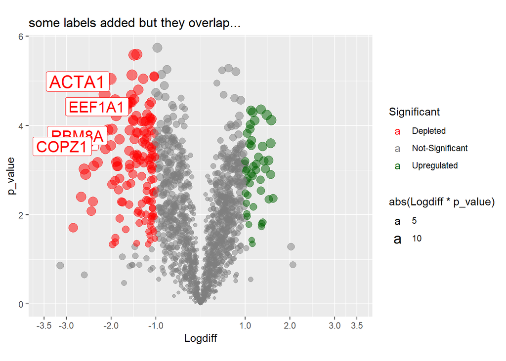

```r
# Shortening genes names by regular expression catching anything until ;
Data_for_Labels$genes <- sub("\\;.*", "", Data_for_Labels$genes)



# Adding labels from addtional dataframe
Vulcan_labels <- Vulcan_size_highliting + geom_label(data = Data_for_Labels, aes(label = genes))+
                                          labs(title = "some labels added but they overlap...")

Vulcan_labels
```

#### Geom_label_repel()

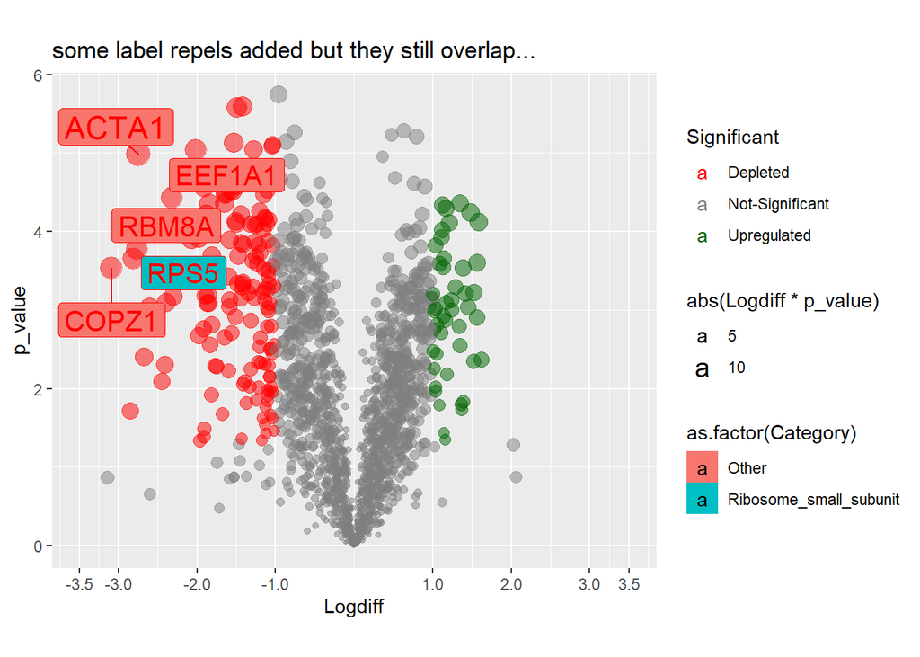

```r
library(ggrepel)

Vulcan_repels <- Vulcan_size_highliting + geom_label_repel(data = Data_for_Labels,
                                                           aes(label = genes, fill = as.factor(Category)))+
                                          labs(title = "some label repels added but they still overlap...")
Vulcan_repels
```

### Polishing the plot for publication quality

```
For publication ready plot we should increase the font size of axis ticks and labels,  erase some legends and create meaningfull titles and subtitles as well as delicate grid background.
```

#### The theme() function eneables customisation of non-data elements of the plot

In ggplot there are some predefined themes such as theme_bw() or theme_minimal() for nice printable plots. However by using theme() you can create your own custom plot appearance. If you wrap it in a function you will be able to use it later for as many plots as you would like.

We modify the plot by arguments of theme() function by atributing their properties to a particular element_X() function call. For example to strip the background we use theme(plot.background = element_blank())

##### Demonstration of different predefined ggplot2 themes

```r
# striping legends
Vulcan_size_highliting <- Vulcan_size_highliting + guides(color = FALSE, fill = FALSE, size = FALSE)

Vulcan_BW <- Vulcan_size_highliting + theme_bw()+labs(title = "Black and White")
Vulcan_Classic <- Vulcan_size_highliting + theme_classic()+labs(title = "Classic")
Vulcan_Void <- Vulcan_size_highliting + theme_void()+labs(title = "Void")
Vulcan_Minimal <- Vulcan_size_highliting + theme_minimal()+labs(title = "Minimal")
Vulcan_Light <- Vulcan_size_highliting + theme_light()+labs(title = "Light")
Vulcan_Dark <- Vulcan_size_highliting + scale_color_manual(values = c("red", "yellow", "green"))+
               theme_dark()+labs(title = "Dark")
```

[output not shown]

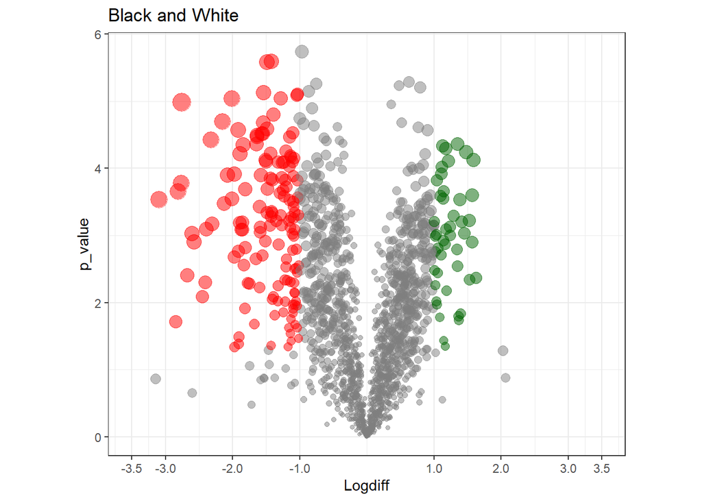

```r
Vulcan_BW
```

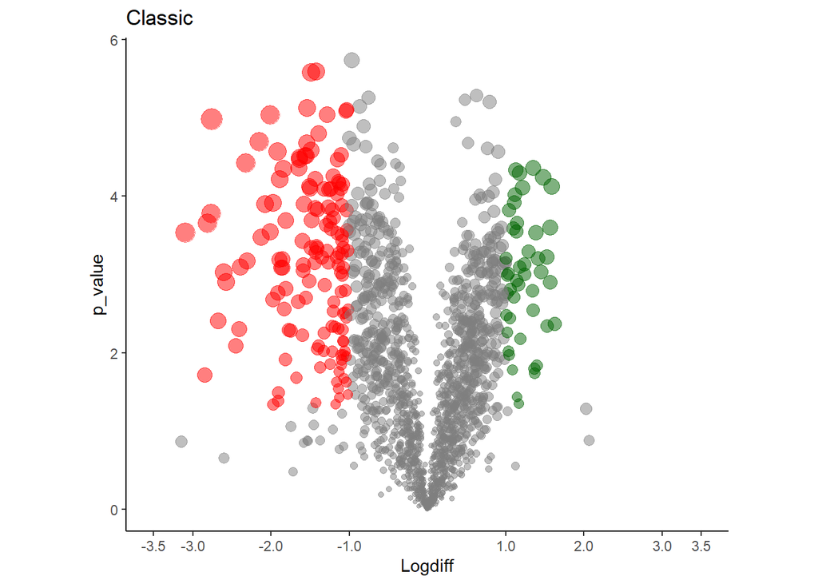

```r
Vulcan_Classic
```

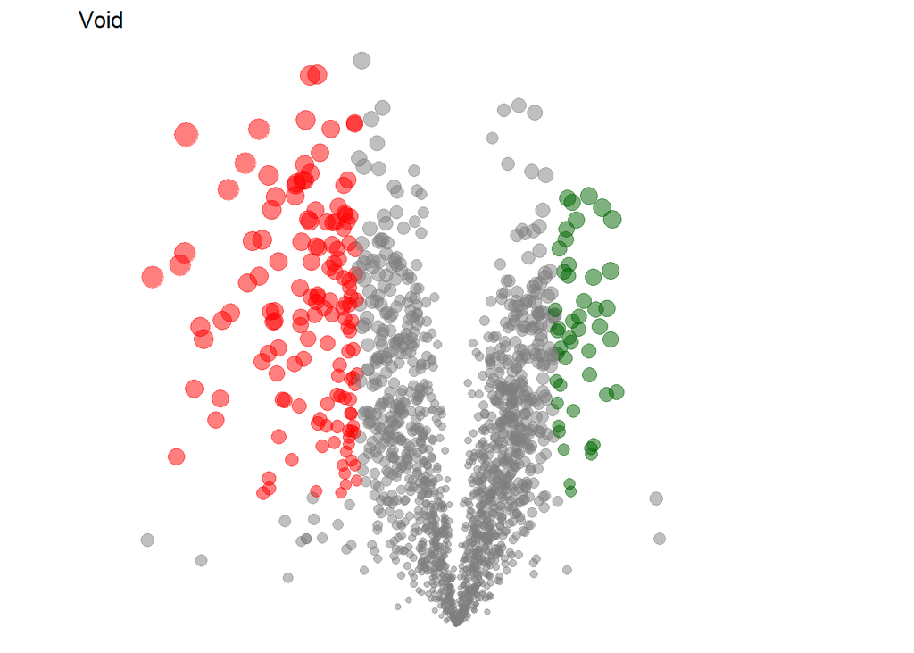

```r
Vulcan_Void
```

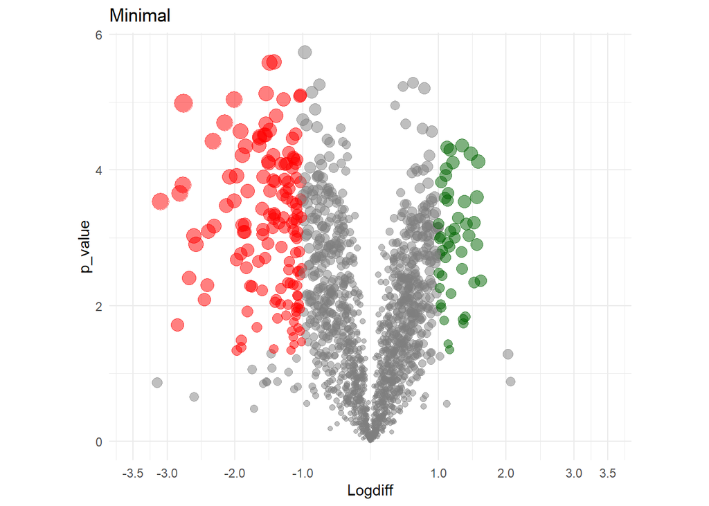

```r
Vulcan_Minimal
```

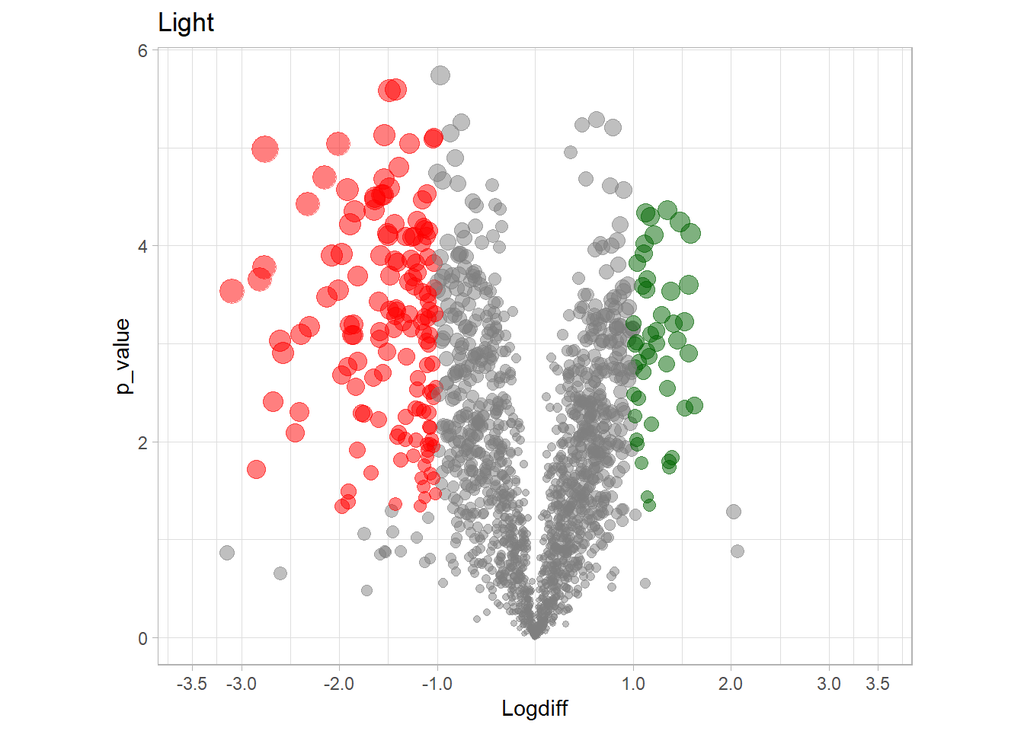

```r
Vulcan_Light
```

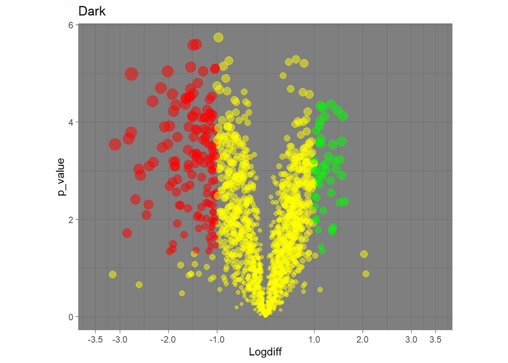

```r
Vulcan_Dark
```

##### Modifying size of the axis ticks and labels

The classic theme looks publishable but we should modyfie it a little bit:

This is how we increase the size of the font in axis title and labels:

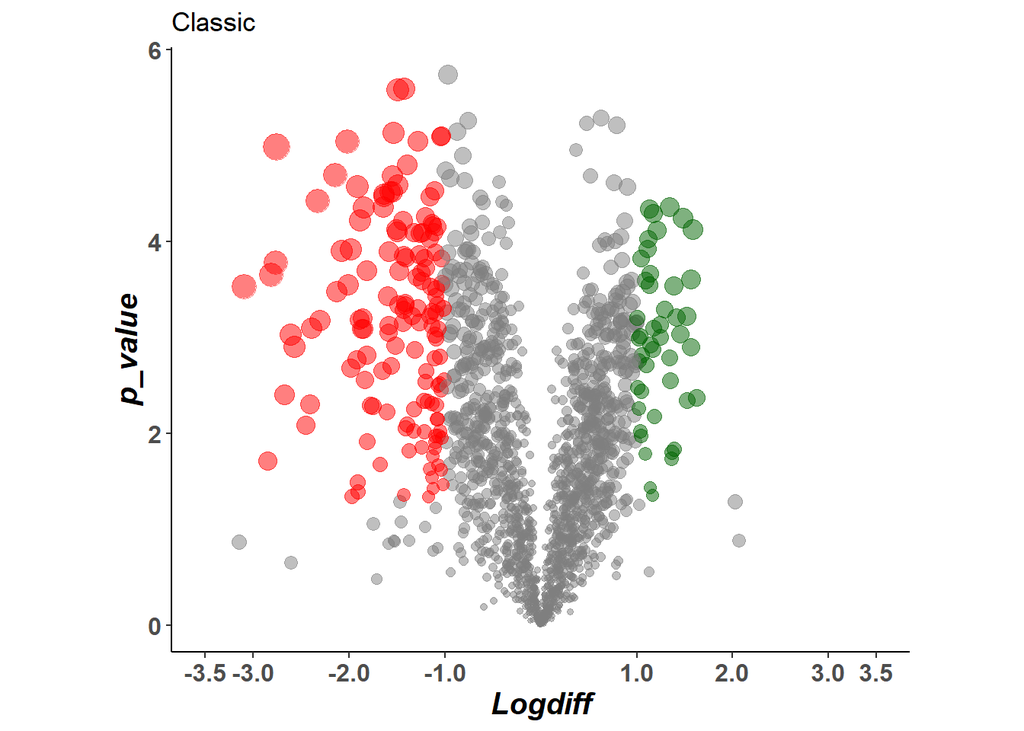

```r
#Increasing the size of the axis
Vulcan_axis_increased <- Vulcan_Classic+theme(axis.text = element_text(size=12, face = "bold"),
                                              axis.title = element_text(size=15, face ="bold.italic"))

Vulcan_axis_increased
```

## The Final publication quality plot

The code for all the steps to create a plot. The plot object can than be exported in Rstudio in to pdf, svg and different types of image files with whatever size and dpi.

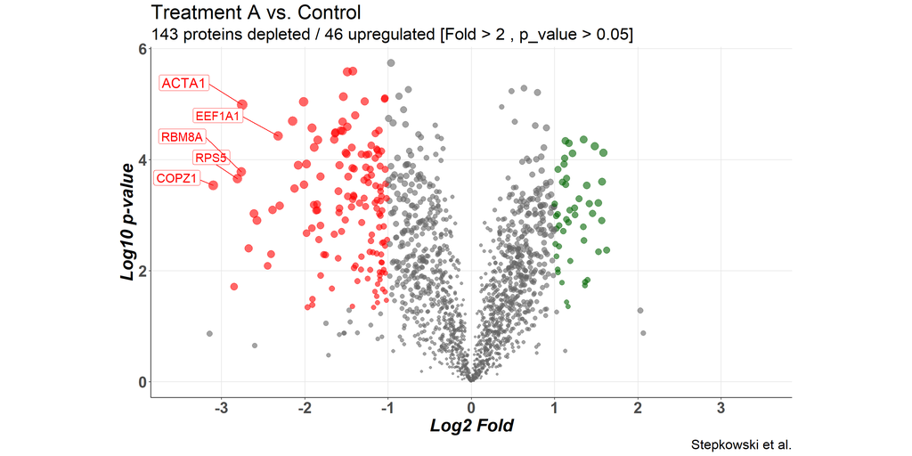

```r
Vulcan_publication <- ggplot(Data_for_Vulcan, aes(x = Logdiff ,
                                                  y = p_value,
                                                  color = Significant,
                                                  size =  abs(Logdiff*p_value*2)))+
                         geom_jitter(alpha = 0.6)+
                         scale_x_continuous(limits = c(-3.5, 3.5),
                                            breaks = c(-3:3))+
                        coord_fixed(ratio = 2/3)+
                        # Adding apropriete titles and subtitles
         labs(title = "Treatment A vs. Control",
                       subtitle = "143 proteins depleted / 46 upregulated [Fold > 2 , p_value > 0.05]",
                       caption  = "Stępkowski et al." )+
                      #axis labels
                         ylab( "Log10 p-value")+
                          xlab( "Log2 Fold")+
                      # changing colors
                      scale_color_manual(values = c("red","gray40", "darkgreen"), na.translate = TRUE)+
                      # labels for top 5 genes
                      geom_label_repel(data = Data_for_Labels,
                                      aes(label = genes),
                                     # label position adjustment,
                                      nudge_x = -0.7,
                                      nudge_y = 0.4,
                                      force = 4
                                      )+

                        # do not show legends
                        guides(color = FALSE, size = FALSE)+

                      # theme customisation
                        theme_classic()+
                        theme(axis.text = element_text(size=20, face = "bold"),
                            axis.title = element_text(size=22,face="bold.italic"),
                            title = element_text(size=21),
                      # adding minir gridlines
                             panel.grid.major =  element_line(colour="gray90", size=0.5)
                            )
Vulcan_publication
```

A Vulcan with categorical data

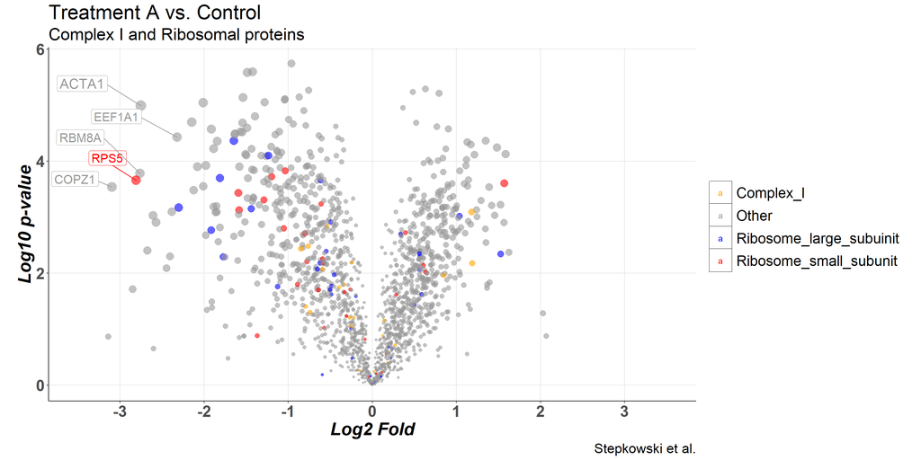

```r
Vulcan_Publication_2 <-   ggplot(Data_for_Vulcan,
                          aes(x = Logdiff ,
                              y = p_value,
                              size = abs(Logdiff*p_value*2),
                              color = Category))+
                        geom_jitter(alpha = 0.6)+
                        scale_x_continuous(limits = c(-3.5, 3.5),breaks = c(-3:3))+
                        coord_fixed(ratio = 2/3)+
                        # Adding apropriete titles and subtitles
                        labs(title = "Treatment A vs. Control",
                           subtitle = "Complex I and Ribosomal proteins",
                           caption  = "Stępkowski et al.")+
                      # Axis labels
                        ylab( "Log10 p-value")+
                        xlab( "Log2 Fold")+
                      # changing colors
                      scale_color_manual(values = c("orange", "gray60", "blue","red"))+
                      # labels for top 5 genes
                      geom_label_repel(data = Data_for_Labels,
                                       aes(label = genes),
                                       #label position adjustment
                                       nudge_x = -0.7,
                                       nudge_y = 0.4,
                                       force = 4
                                       )+

                      # do not show size legends
                      guides(size = FALSE)+

                      # theme customisation
                      theme_classic()+
                      theme(axis.text = element_text(size=20, face = "bold"),
                            axis.title = element_text(size=22,face="bold.italic"),
                            title = element_text(size=21),
                      # adding minor gridlines
                             panel.grid.major =  element_line(colour="gray90", size=0.5),
                      # Increasing the legend keys
                             legend.key.size = unit(1,"cm"),
                             legend.key = element_rect(fill = c("orange", "gray60", "blue","red")),
                             legend.text = element_text(size = 18),
                      # removing legend title and rectangles around keys
                            legend.title = element_blank(),
                            # moving legend to bottom

                            )

Vulcan_Publication_2
```

## Custom ploting function

Lets wrap the above code in a custom ploting function create_vulcan()that could be used for different datasets:

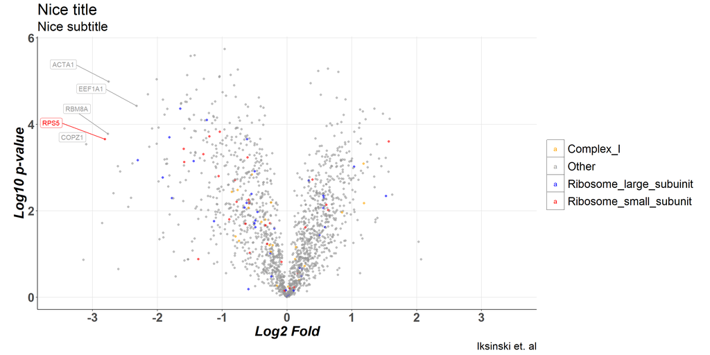

```r
#
create_vulcan <- function(data,
                          xlogs,
                          ypval,
                          names,
                          categorical,
                          title = "title",
                          subtitle = "subtitle",
                          caption = "caption"){ library(dplyr)
    #Arguments data = dataframe, xlogs = column with logs, ypval = column with p_values, categorical
                  #creating size column

                          #this function works only with aes_string and arguments must be passed with ""
   return(ggplot(data, aes_string(x = xlogs,
                              y =ypval,
                              color = categorical))+
                        geom_jitter(alpha = 0.6)+
                        scale_x_continuous(limits = c(-3.5, 3.5),breaks = c(-3:3))+
                        coord_fixed(ratio = 2/3)+
                        # Adding apropriete titles and subtitles
                        labs(title = title,
                           subtitle = subtitle,
                           caption  = caption)+
                      # Axis labels
                        ylab( "Log10 p-value")+
                        xlab( "Log2 Fold")+
                      # changing colors
                      scale_color_manual(values = c("orange", "gray60", "blue","red"))+
                      # labels for top 5 genes
                      geom_label_repel(data = Data_for_Labels,
                                       aes_string(label = names),
                                       #label position adjustment
                                       nudge_x = -0.7,
                                       nudge_y = 0.4,
                                       force = 4
                                       )+

                      # do not show size legends
                      guides(size = FALSE)+

                      # theme customisation
                      theme_classic()+
                      theme(axis.text = element_text(size=20, face = "bold"),
                            axis.title = element_text(size=22,face="bold.italic"),
                            title = element_text(size=21),
                      # adding minor gridlines
                             panel.grid.major =  element_line(colour="gray90", size=0.5),
                      # Increasing the legend keys
                             legend.key.size = unit(1,"cm"),
                             legend.key = element_rect(fill = c("orange", "gray60", "blue","red")),
                             legend.text = element_text(size = 18),
                      # removing legend title and rectangles around keys
                            legend.title = element_blank(),
                            # moving legend to bottom

                            ) )
  }


create_vulcan(Data_for_Vulcan , "Logdiff", "p_value", "genes", "Category", title = "Nice title", subtitle = "Nice subtitle", caption = "Iksiński et. al")
```